# Модел на белодробна вентилация

Доклад за курса във ФМИ "Въведение в изчислителната биология", доц. П. Рашков (ИМИ-БАН), 2018-2019г

Беатрис Бонева

## Цели на проекта

1. Моделиране на физиологичния контрол върху количеството въглероден двуокис в кръвта
2. Изследване на равновесни точки
   - Как тялото стабилизира нивото на $CO_2$?
   - Възможни ли колебания? Кога и от какво възникват?
3. Можем ли да обясним количествено и качествено някои патологични дихателни процеси?

Известно е, че в кръвта се натрупва въглероден двуокис ($CO_2$) като продукт от нормалния метаболизъм на организма. Иначе казано, **въглеродния двуокис се образува от клетките като вторичен продукт**:

[figure not shown]

*[Image Source](https://www.scienceabc.com/humans/why-does-the-human-body-release-carbon-dioxide.html)*

За контролиране нивата на $CO_2$ се грижат **хеморецепторите** в мозъчния ствол:

[figure not shown]

*[Image Source](https://www.youtube.com/watch?v=lVacrVMmJX8)*

При високи нива на $CO_2$ в кръвоносния съд, хеморецепторите не могат да отделят произведения въглероден двуокис в кръвта и той се натрупва около тях. Те реагират на повишените нива на $CO_2$ като изпращат сигнал по невротрансмитерите към дихателните центрове и по този начин скоростта на дишане се контролира физиологично.

[figure not shown]

*[Image Source](https://www.youtube.com/watch?v=lVacrVMmJX8)*

Допускаме, че $CO_2$ се произвежда от тялото с константна скорост (m) и се елиминира през белите дробове със скорост пропорционална на вентилационния обем ($V_n$).

Изменението в количеството $CO_2$ ($C_n$) можем да опишем по следния начин:

$C_{n+1} - C{n} = m - \beta V_n \quad$(1)

Вентилационният обем ($V_n$), който е контролиран от хеморецепторите, е монотонно растяща функция спрямо количеството $CO_2$ в кръвта в по-ранен момент ($C_{n-1}$), т.е. с нарастването на количеството $CO_2$, нараства и вентилационния обем. Нека да вземем линейната функция:

$V_{n} = \alpha C_{n-1}, \quad \alpha > 0 \quad$ (2)

Всъщност, това "закъснение" (зависимостта от по-предходен момент) идва от времето, необходимо на кръвта да достигне хеморецепторите.

Ако фиксираме $C$ и $V$ така, че изменението в количеството $CO_2$ ($C_n$) и съответно и във вентилационния обем да е 0 (равновесна точка, $C_{n+1} = C_n, V_{n+1}=V_n$), от (1) следва, че:

$m - \beta \bar{V} = 0 \implies \bar{V} = \frac{m}{\beta}$

и от (2) намираме равновесната точка и за $C$: $\bar{C} = \frac{m}{\alpha \beta}$.

Да изследваме равновесната точка за устойчивост:

$ \begin{cases} C_{n+1} = C_n - \beta V_n + m\\ V_{n} = \alpha C_{n-1} \end{cases}\implies \quad C_{n+1} = C_n - \alpha \beta C_{n-1} + m$

- Ако $m = 0$, уравнението е хомогенно. Разглеждаме характеристичния му полином:

  $x^2 = x - \alpha \beta$

  Той има корени $x_{1;2} = \frac{1 \pm \sqrt{1 - 4 \alpha \beta}}{2}$

  Тогава общото решение на хомогенното уравнение е: $A(n) = C_1 (\frac{1 + \sqrt{1 - 4 \alpha \beta}}{2})^n + C_2 (\frac{1 - \sqrt{1 - 4 \alpha \beta}}{2})^n $, където $C_1$ и $C_2$ са константи зависещи от началните условия.
- Ако $m \neq 0$, уравнение е нехомогенно. Търсим частно решение от вида $B(n) = k, k - const$. Вече знаем, че равновесната точка $\frac{m}{\alpha \beta}$ е решение.

  Следователно, общото решение на нехомогенното уравнение е: $C_n = A(n) + B(n) = C_1 (\frac{1 + \sqrt{1 - 4 \alpha \beta}}{2})^n + C_2 (\frac{1 - \sqrt{1 - 4 \alpha \beta}}{2})^n + \frac{m}{\alpha \beta}$.

Разглеждаме модул от собствените стойности $\mid\frac{1 + \sqrt{1 - 4 \alpha \beta}}{2}\mid$ и $\mid\frac{1 - \sqrt{1 - 4 \alpha \beta}}{2}\mid$.

- Нека $4\alpha \beta < 1$.

  От $\sqrt{1 - 4 \alpha \beta} < 1 \implies$ и двете собствени стойности са $< 1$.

  Следователно, равновесните точки $\bar{C} = \frac{m}{\alpha \beta}$ и $\bar{V} = \frac{m}{\beta}$ са устойчиви.

  Тоест, нивото на въглероден двуокис и вентилационния обем ще се стабилизират в тези точки независимо от началните условия.

  Да видим:

```python
def linear_model(iterations, alpha=None, beta=None, m=None, c0=1, v0=1):
    result = [[c0, v0]]
    c_current = c0
    v_current = v0
    for _ in range(iterations):
        v_next = alpha * c_current
        c_next = c_current - beta * v_current + m
        result.append([c_next, v_next])
        c_current = c_next
        v_current = v_next
    return result


def plot_model(result):
    ll = plt.plot(result)
    xl = plt.xlabel('Време')
    plt.legend(ll, ["Количество $CO_2$", "Вентилационен обем"])
    plt.show()
```

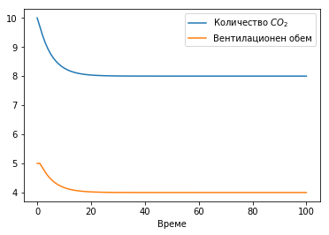

```python
plot_model(linear_model(100, alpha=0.5, beta=0.3, m=1.2, c0=10, v0=5.0))
```

Виждаме, че количеството въглероден двуокис ($C_n$) се стабилизира в точка $\frac{m}{\alpha \beta} = \frac{1.2}{0.5*0.3} = 8$, a вентилационният обем в $\frac{m}{\beta} = \frac{1.2}{0.3} = 4 $.

Дори и да променим стойностите на константите $C_1$ и $C_2$, зависещи от началните условия, $C_n$ и $V_n$ отново ще се стабилизират в същите точки:

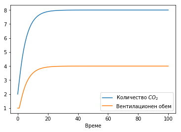

```python
plot_model(linear_model(100, alpha=0.5, beta=0.3, m=1.2, c0=2, v0=1))
```

- Нека $4\alpha \beta > 1$. Тогава равновесните точки $\bar{C} = \frac{m}{\alpha \beta}$ и $\bar{V} = \frac{m}{\beta}$ няма да са устойчиви. За някои стойности в този интервал се наблюдават колебания в количеството въглероден двуокис и вентилационния обем, а за други настъпва хаос.

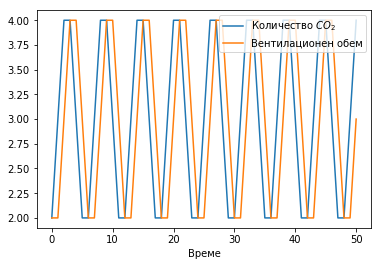

```python
plot_model(linear_model(50, alpha=1, beta=1, m=3, c0=2, v0=2)) # alpha*beta = 1
```

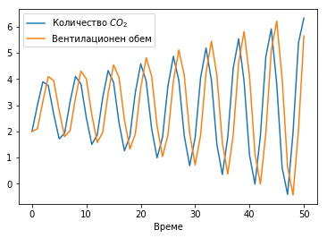

```python
plot_model(linear_model(50, alpha=1.05, beta=1, m=3, c0=2, v0=2)) # alpha*beta = 1.05
```

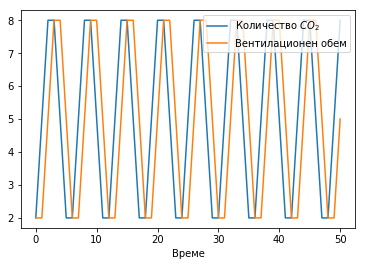

```python
plot_model(linear_model(50, alpha=1, beta=1, m=5, c0=2, v0=2)) # alpha*beta = 1
```

Забелязва се, че при нарастване на $\alpha \beta$ и на $m$, колебанията растат.

Можем да заключим, че при нарастване на някое от:

- чувствителността на хеморецепторите;
- количеството въглероден двуокис, което тялото произвежда; системата става нестабилна и може да започне да осцилира.

Тези наблюдения могат да обяснят защо при повишено вътречерепно налягане (появя се при инсулти, мозъчни тумори, сърдечна недостатъчност и др.) или хора с надмормено тегло (при които се произвежда повече $CO_2$) се наблюдава неравномерно дишане. Пример за това е патологичното Чейн-Стоксово дишане. Дълбочината на дихателните движения постепенно се увеличава, след което също така плавно намалява. Следва период на апнея и нов цикъл от постепенно задълбочаващи се и след това затихващи дихателни движения:

[figure not shown]

Графично, стабилизирането на системата изглежда така:

[figure not shown]

Всякакъв малък спад в количеството вентилирано през белите дробове ($A$) води до повишение на количеството $CO_2$ в кръвта ($A'$), което се засича от хеморецепторите и за да се компенсира, се увеличава вентилационния обем (B) над равновесната му точка (S) и по този начин количеството $CO_2$ се връща в равновесната точка. (Така наречената "feedback" система.)

При патологичното дишане, вентилационният обем се увеличава повече от необходимото и образува обратно по посока колебание. Ако вторичното колебание е дори по-голямо от първоначалното, следващото ще е още по-голямо и т.н., докато не се образуват много големи осцилации и докато не стигне критична точка като например вентилационният обем да стане 0. Затова и при Чейн-Стоксово дишане се наблюдава цикличност.

[figure not shown]

Нека количеството $CO_2$ вентилирано през белите дробове да зависи и от количеството на $CO_2$ в сегашния момент, а не само от венталиционния обем, т.е. $\mathbf{L(V_n, C_n) = \beta V_n C_n}$.

Тогава

$\begin{cases} C_{n+1} = C_n - \beta V_n C_n + m\\ V_{n+1} = \alpha C_{n} \end{cases}\Leftrightarrow \begin{cases} C_{n+1} = C_n - \beta V_n C_n + m\\ V_{n} = \alpha C_{n-1} \end{cases}$

Като заместим $V_n$ в уравнението за $C_{n+1}$ получаваме едно уравнение за $C$:

$\mathbf{C_{n+1} = C_n - \alpha \beta C_n C_{n-1} + m}$

Търсим равновесна точка, т.е. точка за която $C_{i+1} = C_i = \bar{C}, \quad \forall i > i' \iff \bar{C} = f(\bar{C})$. Тогава:

$f(C) = \bar{C} - \alpha \beta \bar{C}^2 + m$

$\bar{C} = f(\bar{C}) \Leftrightarrow \bar{C} = \bar{C} - \alpha \beta \bar{C}^2 + m \implies \alpha \beta \bar{C}^2 = m \implies \bar{C}^2 = \frac{m}{\alpha \beta} \implies \bar{C} = \sqrt{\frac{m}{\alpha \beta}}$

Изследваме равновесната точка за устойчивост. (За да е устойчива равновесната точка, трябва $\mid f'( \bar{C})\mid < 1$.)

$\mid f'( \bar{C})\mid = \mid \bar{C} - \alpha \beta \bar{C}^2 + m \mid \quad \Leftrightarrow \quad \mid f'( \bar{C})\mid = \mid - 2 \alpha \beta \mid$

и съответно $\bar{V} = \alpha \bar{C}$.

Да изследваме модела при тези условия:

```python
def nonlinear_model(iterations, alpha=None, beta=None, m=None, c0=1, v0=1):
    result = [[c0, v0]]
    c_current = c0
    v_current = v0
    for _ in range(iterations):
        c_next = c_current - beta * c_current * v_current + m
        v_next = alpha * c_current
        result.append([c_next, v_next])
        c_current = c_next
        v_current = v_next
    return result
```

При $\alpha \beta < \frac{1}{2}$:

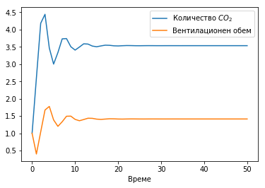

```python
plot_model(nonlinear_model(50, alpha=0.4, beta=0.4, m=2, c0=1, v0=1))
```

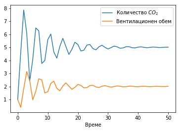

```python
plot_model(nonlinear_model(50, alpha=0.4, beta=0.4, m=4, c0=1, v0=1))
```

Виждаме, че при по-голямо количество произведен въглероден диоксид от тялото, колебанията в началото са по-големи и системата се стабилизира след повече итерации.

При $\alpha \beta > \frac{1}{2}$ отново, както при линейната система, възникват колебания:

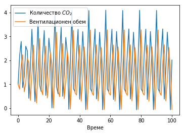

```python
plot_model(nonlinear_model(100, alpha=0.8, beta=0.8, m=2, c0=1, v0=1))
```

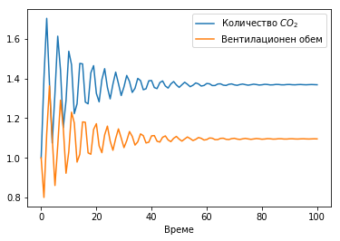

```python
plot_model(nonlinear_model(100, alpha=0.8, beta=0.8, m=1.2, c0=1, v0=1))
```

Интересно е, че за достатъчно малки стойности на произведения $CO_2$ ($m$) системата може и да успее да се стабилизира, но при по-големи дори и след голям брой итерации това не се случва:

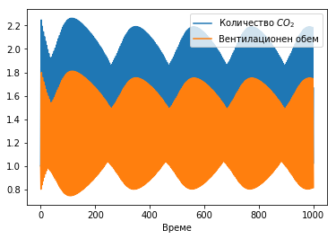

```python
plot_model(nonlinear_model(1000, alpha=0.8, beta=0.8, m=1.6, c0=1, v0=1))
```

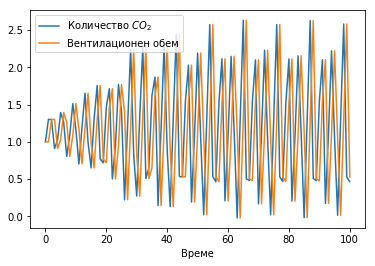

```python
plot_model(nonlinear_model(100, alpha=1, beta=1, m=1.3, c0=1, v0=1))
```

## Сигмоидна функция за $S(C)$

Mackey и Glass (1977, 1978) разглеждат сигмоидна функция за чувствителността на хеморецепторите,

$S(C) = \frac{C^l}{K^l + C^l}$, с параметри $l \in \mathbb{N}, K \in \mathbb{R}$.

Нека $V_{n+1} = V_{max}S(C_n)$, където $V_{max}$ е максималният обем.

За $L(V_n, C_n)$ запазваме нелинейната зависимост $L(V_n, C_n) = \beta V_n C_n$.

Тогава

$\begin{cases} C_{n+1} = C_n - \beta V_n C_n + m\\ V_{n+1} = V_{max}\frac{C_n^l}{K^l + C_n^l} \end{cases}\Leftrightarrow \begin{cases} C_{n+1} = C_n - \beta V_n C_n + m\\ V_{n} = V_{max}\frac{C_{n-1}^l}{K^l + C_{n-1}^l} \end{cases} $.

Като заместим $V_n$ в уравнението за $C_{n+1}$ получаваме едно уравнение за $C$:

$\mathbf{C_{n+1} = C_n - \beta C_n V_{max}\frac{C_{n-1}^l}{K^l + C_{n-1}^l} + m}$

Да разгледаме функцията $S(C) = \frac{C^l}{K^l + C^l}$.

$l$ се нарича *параметър на кооперативност*, т.е. при $l > 1$ свързването на единична молекула към хеморецептора повишава вероятността за допълнително свързване.

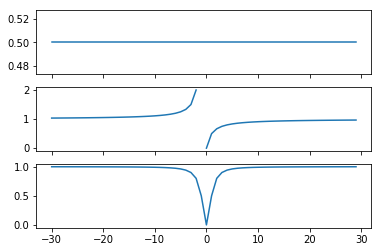

```python
C = np.arange(-30, 30)
f, (ax1, ax2, ax3) = plt.subplots(3, 1, sharex=True)
ax1.plot(C, s(C, K=1, l=0));ax2.plot(C, s(C, K=1, l=1));ax3.plot(C, s(C, K=1, l=2));plt.show()
```

Функцията е прекъсната в $-K$, но ние се интересуваме от стойности по-големи от 0 за $C$.

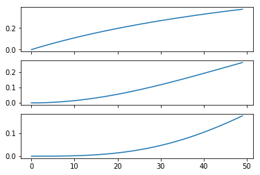

```python
C = np.arange(0, 50)
f, (ax1, ax2, ax3) = plt.subplots(3, 1, sharex=True)
ax1.plot(C, s(C, K=82, l=1));ax2.plot(C, s(C, K=82, l=2));ax3.plot(C, s(C, K=82, l=3));plt.show()
```

```python
def model(iterations, K=None, l=None, beta=None, m=None, v_max=None, c0=None):
    c_current = c0
    v_current = v_max * s(c_current, K=K, l=l)
    result = [[c_current, v_current]]
    for _ in range(iterations):
        v_next = v_max * s(c_current, K=K, l=l)
        c_next = c_current - beta * c_current * v_current + m
        result.append([c_next, v_next])
        c_current = c_next
        v_current = v_next
    return result
```

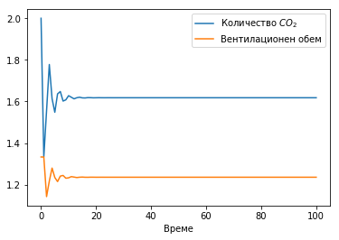

```python
plot_model(model(100, K=1, l=1, beta=1, m=2, v_max=2, c0=2))
```

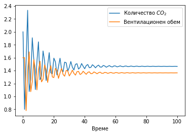

```python
plot_model(model(100, K=1, l=2, beta=1, m=2, v_max=2, c0=2))
```

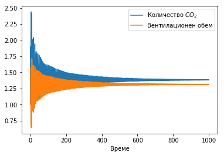

```python
plot_model(model(1000, K=1, l=2, beta=1.1, m=2, v_max=2, c0=1))
```

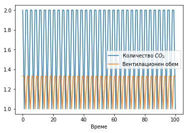

```python
plot_model(model(100, K=1, l=1, beta=1.5, m=3, v_max=2, c0=2))
```

## Използвана литература

#### Научни статии

- M.C. Mackey, L. Glass (1977). Oscillation and chaos in physiological control systems, Science 197: 287-289.
- L. Glass, M.C. Mackey (1978). Pathological conditions resulting from instabilities in physiological control systems, Ann. NY Acad. Sci. 316: 214-235.
- M.C. Mackey, J. Milton (1987). Dynamical diseases, Ann. NY Acad. Sci. 504: 16-32.

#### Други източници

- Лекционни материали към курса във ФМИ "Въведение в изчислителната биология", доц. П. Рашков (ИМИ-БАН), 2018-2019г
- https://en.wikipedia.org/wiki/Cheyne%E2%80%93Stokes_respiration